# Supervised and unsupervised learning with baseline scores and progression rates of markers from structural MRI and cognitive assessments

#### Project Work of Patric Wyss for the courses Data Science Fundamentals 1-5

## 1) Overview and set-up

### 1.1) Overview of the five different courses

This notebook contains analyses for the course work of the course data science fundamentals. It covers a data set of multiple longitudinally assessed markers from cogntively impaired patients (see below for more information). All courses 1-5 were heplful for this work, here a short overview

- Modul 1: Basics needed in all parts (indexing, functions, ...)
- Modul 2: Not used much of it. In future I will write own modules containing all the functions. Here I included the own functions when there were first used such that it is easier to follow what was done
- Modul 3: Used in all parts of this course work (all data management with panda)
- Modul 4: I implemented linear models and significance tests to examine differecnes in means between different patient groups
- Modul 5: This was the main focus. On one hand I performed unsupervised approaches to exmaine structure in the data and reduce the dimensionality of the data. On the other hand, I was interested in predicting cognitive decline (regression) or clinical diagnoses (classification). Given the number of subjects and features as well as the time needed for training I did not implement all algorithms learned in this course. E.g., I focused on the libary "sklearn" and did not implement neural networks.

The main focus was: Finding the best underlying structure of the data (unsupervised) by using performance measures for the prediction of external criteria (cognitive decline, clinical diagnoses). I used the data with reduced dimensionality (with PCA, clustering) in supervised approaches and focussed on performance metrics for predicting the external criteria rather than performance measures based on the features used for unsupervised learning itself (e.g. explained variance in PCA)

### 1.2) Set-up

#### Libraries

```python
import os
import glob
import numpy as np
from numpy import vectorize
import pandas as pd
from matplotlib import pyplot as plt
import statistics

import random
import scipy.stats as stats
#import umap

## data management
from sklearn.model_selection import train_test_split
from sklearn import preprocessing
from sklearn import metrics

## regression and classification
from sklearn import linear_model
from sklearn import tree
from sklearn import ensemble

## Unsupervised: Continious
from sklearn.decomposition import PCA
from sklearn.manifold import TSNE

## Unsupervised: clustering
from sklearn.mixture import GaussianMixture
from sklearn.cluster import KMeans
from sklearn.metrics import silhouette_score
```

```python
# set the seed
np.random.seed(131820)
```

#### Data

In my PhD project "Data-driven subject profiling and stageing in ageing and demenatia" we are focussing on the analyses of mutlivariate, repeatedly assessed markers. We used two publicly available data sets (ADNI and AIBL). One main directions is focussing on linear-mixed effects models for the analyses of multivariate, longituidnal data to predict latent variables covering the structure of the data, future response values or external criteria. We implemented a framwork for generative classification (Wyss et. all 2021). As in this study we are also using for this course work a data set consiting of subjects that start with the clinical label "Mild cogntive impairements" (MCI) and either stay with this label for at least 3 years or convert to the stadium Alzheimers dementia (AD) within a maximum of 3 years. We call this two groups of patients "MCI-stables" and "MCI-converters". In this course work we are using an implementation to predict subject-specific random intercepts and slopes in time (another implementation than in Wyss et al (2021)). These random effects are predicted using univariate, linear mixed-effects models. The model uses the age at first visit (baseline-age) and the time since baseline as independent variables to predict the marker values over time. Besides so called fixed-effects that can be used to predict population-level means, the model also include random effects that determine the variance-covariance structure. Moreover, within our cross-validation framwork the random effects can be predicted for given values of observed response values. The subject-specific (random) intercept in time is the deviation of the population-level intercept of a population with same baseline age. Hence, these intercepts are adjusted for ageing differnces in the markers given by their age at study entry. Subjects with positive values of the random intercepts have values above the average of the population of subjects with same baseline age (negative below average). The subject-specific (random slopes) in time are the random deviations of the slope in time of the marker from the population level slopes. We considered different markers, i.e. cognitive or biological from structural MRI. More precisely, we consider here the cognitive markers MMSE and RAVLT as well as volumes of regions of interest (have "H_MUSE" in the column name) and a summary score called SPARE-AD score. The SPARE-AD score quantifies how "AD-like" the structure of brain is.

With the code below the data frame is created. In the directory given by the object "path" there are multiple (27) files contaiing intercepts and slopes for different markers. We read them in and merge them into one file as follows

```python
path = r'C:/Users/pw18y127/Desktop/lastYear/DSF_py/pycourse/data/ranef/lme4'
all_files = glob.glob(path + "/*.csv")

for f in all_files:
    dataTemp = pd.read_csv(f)
    if f==all_files[0]:
        dataRanef = dataTemp
    else:
        dataRanef = pd.merge(dataRanef, dataTemp)

dataRanef.shape
#dataRanef
```

```
(582, 523)
```

Now subsets of the data set are built for the different analyes that are performed afterwards. Moreover, all these data sets are also standardized (important for e.g. PCA)

```python
# data set containing random effects for the volumes of the region of interest
data_mri = dataRanef.filter(regex='H_MUSE')
x_mri=preprocessing.scale(data_mri)

# data containing random effects of SPARE-AD score and cognitive markers
data_spareKog=dataRanef[["random_.Intercept._SPARE_AD", "random_Time_SPARE_AD", "random_.Intercept._MMSE", "random_Time_MMSE", "random_.Intercept._RAVLT", "random_Time_RAVLT"]]
x_spareKog=preprocessing.scale(data_spareKog)

# data set containing random effects of SPARE-AD score only
data_spare=dataRanef[["random_.Intercept._SPARE_AD","random_Time_SPARE_AD"]]
x_spare=preprocessing.scale(data_spare)

# vector containing all values representing cognitive decline
# operationalized with the random effect in time for MMSE
y=dataRanef["random_Time_MMSE"]

# bector containing all diagnoses, i.e. D0 (MCI-stable) ir D1 (MCI-converter)
d=dataRanef["Diagnosis"]
```

## 2) Unsupervies learning

In this section we are examine the structure in the data sets using unsupervised learning techniques. We are using here all data and do not perform a split into training and test set (in the next section covering regression and classification we will).

### 2.1) Dimension reduction with PCA (and t-SNE)

#### Functions

First we include our own functions for data analyses with PCA (will also be used in later sections)

```python
# Function to fit PCA and present the results
def pcaFitPlot(data, nrPc):
    # Fir PCA to data
    pca=PCA(n_components=nrPc)
    pca.fit(data)

    # print explained variances of PCs
    print(pca.explained_variance_ratio_)

    # plot explained variance
    plt.plot(pca.explained_variance_ratio_,'-o')
    plt.title('Scree plot')
    plt.ylabel('Percentage of explained variance')
    plt.grid()
    plt.show()

    return(pca)

# Function to fit PCA to two-dimensional data and visualize reconstruction on first PC
def plotReconstructPca2d(data_train, data_test, col):
    # Fit PCA to training data and represent results
    # (see function pcaFitPlot)
    pca_train=pcaFitPlot(data_train, 2)

    # extract the scores on the PCAs for test data
    scores=pca_train.transform(data_test)

    # Compute reconstruction on first PC
    res=np.dot(scores[:,:1], pca_train.components_[:1,:])

    # Plot result
    plt.figure(figsize=((5,5)))
    plt.title('Reconstruction with first principal component')
    plt.plot(data_test[:,0],data_test[:,1],'o', c=col)
    plt.plot(res[:,0],res[:,1],'o', c="red")
    plt.grid()
    plt.show()
```

#### 2.1.1) SPARE-AD

We start with analyses using the random intercepts and slopes of the SPARE-AD (higher values mean more "AD-like" respectively getting more "AD-like" faster).

```
[0.75379518 0.24620482]
```

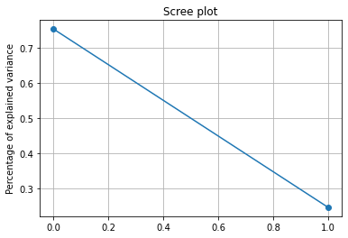

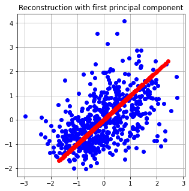

```python
#colPlot=np.full((x_spare.shape[0], 1), 1)
#colPlot = np.array(colPlot)
plotReconstructPca2d(x_spare, x_spare, "blue")
```

#### 2.1.2) SPARE-AD and cognitive markers

Now we include also the random intercepts and slopes of the cognitve markers. The test results measure cognitive abilities, hence higher values indicate better cognition (intercept) respectively slower cognitive decline (slope).

```
[0.57379869 0.14400696 0.09335182 0.07596999 0.06578195 0.04709058]
```

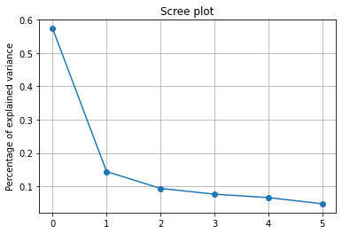

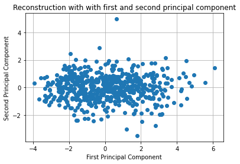

```python
# Now we include the scores from the cognitive measures
## Fit model and compute the scores
pca_spareKog=pcaFitPlot(x_spareKog, x_spareKog.shape[1])
scores_spareKog=pca_spareKog.transform(x_spareKog)

# plot scores on first two PCs
plt.plot(scores_spareKog[:,0], scores_spareKog[:,1],'o')
plt.title('Reconstruction with with first and second principal component')
plt.ylabel('Second Principal Component')
plt.xlabel('First Principal Component')
plt.grid()
plt.show()


x_spareKog_pca=scores_spareKog[:,:1]
```

#### 2.1.3) Volume scores of all regions of interest

```
#----------- first 20 PCs
[0.25555827 0.17728426 0.06780209 0.02753135 0.02056255 0.01939077
 0.01728181 0.01545569 0.0144273  0.01281882 0.01107421 0.01083285
 0.01013768 0.00967967 0.00864066 0.00860642 0.00804089 0.00762616
 0.00682569 0.00673152]
```

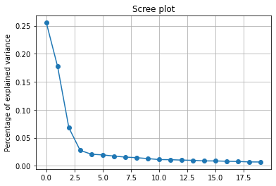

```python
# plot all PCs (>500)
#print("#----------- maximum number of possible PCs (number of features)")
#pca_mri=pcaFitPlot(x_mri,  x_mri.shape[1])

# plot only the first 20 PCs
print("#----------- first 20 PCs")
pca_mri=pcaFitPlot(x_mri,  20)
```

Less than 5% of additional explained variance with 4th PCs, less than 1% with 14th PC

### 2.2) Clustering

#### Functions

First we include our own functions for data analyses with clustering (will also be used in later sections)

```python
def perfClust(data, meth, clustRange):
    # Initialize output, i.e. performances silhoutte score or AIC/BIC (for mixture of Gaussian)
    bic=[]
    sil=[]

    # loop over the consider range of number of clusters
    for nrClust in clustRange:

        # Initialize model either k means or mixture of Gaussian
        if meth=="kMeans":
            clustTemp = KMeans(n_clusters=nrClust, random_state=10)
        if meth=="GM":
            clustTemp =  GaussianMixture(n_components=nrClust, covariance_type='full')

        # Fit model on data
        clustTemp.fit(data)

        # predict cluster label for training set
        cluster_labels=clustTemp.predict(data)

        # compute silhoutte score for cluster solution
        score=silhouette_score(data, cluster_labels)

        # append it to the output object
        sil.append(score)

        # Compute AIC and BIC (only in case we use mixture of Gaussian)
        if meth=="GM":
            bic.append(clustTemp.bic(data))

    # plot results to choose best cluster solution
    plt.xlabel('Number of clusters')
    plt.ylabel('Silhouette score')
    plt.plot(np.arange(len(sil))+2, sil,'-o')
    plt.show()

    # return Siloutte score for k means
    if meth=="kMeans":
        return(sil)

    # Visualize AIC and BIC for mixture of Gaussian
    # and return all performance measures
    if meth=="GM":

        plt.figure()
        plt.xlabel('Number of clusters')
        plt.ylabel('BIC')
        plt.plot(np.arange(len(bic))+2, bic,'-o')
        plt.show()
        return([sil, bic])
```

#### 2.2.1) SPARE-AD

We start with the clustering using only the random intercept and slope of the SPARE-AD score. As described above, the data is coming from two groups with different diagnoses (converters and stables), so first we want to see how this two population scatter in this two features:

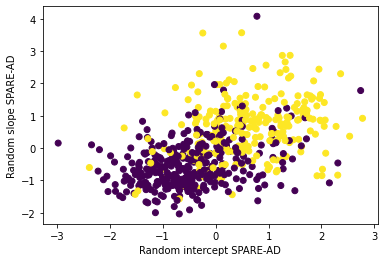

```python
# Build color according to diagnosis
def colorDiag(diag):
     if diag=="D0":
          return 0
     else:
          return 1

vColorDiag = vectorize(colorDiag)
diag_labels= vColorDiag(d)

# Plot features
plt.figure()
plt.scatter(x_spare[:,0],x_spare[:,1],c=diag_labels)
plt.ylabel('Random slope SPARE-AD')
plt.xlabel('Random intercept SPARE-AD')
plt.show()
```

Converters (yellow dots) showed higher random intercepts and slopes than stables (purple dots), i.e., converters tend to be more AD-like in the beginning and become more AD-like over time faster.

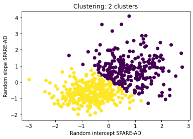

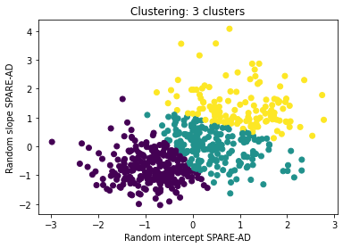

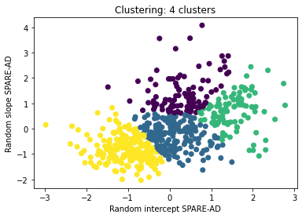

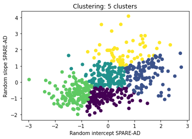

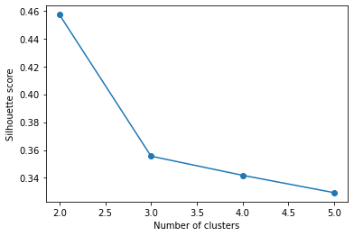

```python
# Fit clustering model and visualize assignments
# (only mixture of Gaussian)
for nrClust in range(2,6):
    clustTemp = KMeans(n_clusters=nrClust, random_state=10)
    cluster_labels = clustTemp.fit_predict(x_spare)
    plt.figure()
    plt.scatter(x_spare[:,0],x_spare[:,1],c=cluster_labels)
    plt.title("Clustering: "+str(nrClust) + " clusters")
    plt.ylabel('Random slope SPARE-AD')
    plt.xlabel('Random intercept SPARE-AD')
    plt.show()

# Compute performance of cluster solutions
## for k means
clustPerfSpare=perfClust(x_spare, "kMeans", range(2, 6))
```

According to the silhoutte score (computed on training data!), the two-cluster solution is the best one.

#### 2.2.2) SPARE-AD and cognitive markers

```
#---------- k Means
```

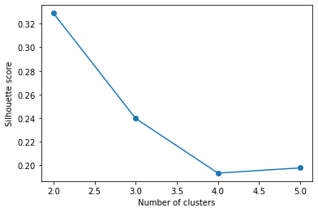

```
#---------- Mixture of Gaussian
```

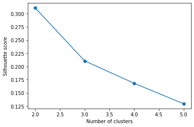

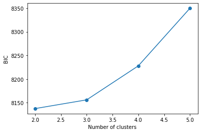

```python
# Compute performance of cluster solutions
## for k means
print("#---------- k Means")
clustPerfSpareKog1=perfClust(x_spareKog, "kMeans", range(2, 6))

print("#---------- Mixture of Gaussian")
## for mixture of Gaussian
clustPerfSpareKog2= perfClust(x_spareKog, "GM", range(2, 6))
```

All criteria (for both k Means and Mixture of Gaussian) revealed that the two-cluster solution is the best (highest Silhoutte score and lowest BIC).

#### 2.2.3) Volume scores of all regions of interest

We performed the same analyses using the random intercepts and slopes in the volumes of all considered ROIs (number of features >500)

```
#---------- k Means
```

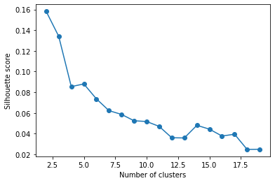

```
#---------- Mixture of Gaussian
```

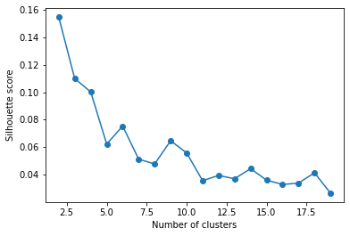

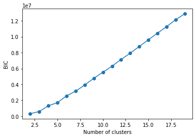

```python
# Compute performance of cluster solutions
## for k means
print("#---------- k Means")
clustPerfMri1= perfClust(x_mri, "kMeans", range(2, 20))

## for mixture of Gaussian
print("#---------- Mixture of Gaussian")
clustPerfMri2= perfClust(x_mri, "GM", range(2, 20))
```

According to the Silhoutte score of both k Means and mixture of Gaussian models, a two cluster solution fits the best. Also the BIC was the lowest for two cluster mixture of Gaussian models.

## 3) Supervised Learning

After exploring the data with unspupervised techniques I implemented in a next step supervised approaches to predict random effects of markers (regression) or the clinical diagnosis e.g. MCI-stables or MCI-converters (classification). On one hand we used the random-effects itself as featrures, on the other hand we also used reduced-feature spaces for predictions given either by PCA or clustering.

#### Functions

I include here all the functions that are used in chapter 3:

```python
def sigTestLocation(valgroup1, valgroup2):
     #assumption: normal with same variances
        print("#-- Test normal")
        k1, p1 = stats.normaltest(valgroup1)
        print("p-value group 1 = %1.2f" % p1)

        k2, p2 = stats.normaltest(valgroup2)
        print("p-value group 2 = %1.2f" % p2)

        # t-Test means equal variance
        print("#-- t-Test equal variances")
        print(stats.ttest_ind(valgroup1, valgroup2, equal_var = True))

        # t-Test of means unequal variance
        print("#-- t-Test equal variances")
        print(stats.ttest_ind(valgroup1, valgroup2, equal_var = False))

        # mann withney test of location
        print("#-- Mann Withney")
        print(stats.mannwhitneyu(valgroup1, valgroup2))

# Function that fits different classifcation models (logistic regression, decsion tree, random forest and boosted trees)
# on training data, makes prediction on a test set# and computes the performances of the classifiers
# Arguments:
# pred_train        data containing features of the subject in the training set
# class_train       vector containing diagnoses of the subjects in the trainining set
# pred_test         data containing feautres of the subjects in the test set
# class_test        vector containing diagnoses of the subjects in the test set
# rangeDecTree      range of model complexitity for decision trees
# rangeRandForest   range of model complexitity for random forest
# rangeBoostTree    range of model compexitivy for boosted trees
def classPerfFun(pred_train, class_train, pred_test, class_test, rangeDecTree, rangeRandForest, rangeBoostTree):
    # Analyses with logistic regression
    print("#------logistic regression")
    print("")
    ## Fit model
    logReg=linear_model.LogisticRegression()
    logReg.fit(pred_train, class_train)

    ## Print performance
    print("training accuracy= %.3f" % logReg.score(pred_train,  class_train))
    print("test accuracy= %.3f" % logReg.score(pred_test, class_test))

    # Analyses with decision trees
    print("")
    print("#------Decision Tree")
    ## loop over the range of considered depths
    for depth in rangeDecTree:
        print(depth)

        ### Fit model
        decTree=tree.DecisionTreeClassifier(max_depth=depth)
        decTree.fit(pred_train, class_train)

        # Print performance
        print("training accuracy= %.3f" % decTree.score(pred_train, class_train))
        print("test accuracy= %.3f" % decTree.score(pred_test, class_test))

    # Analyses with random forest
    print("")
    print("#------Random Forest")

    ## loop over the range of considered number of estimators
    for n_est in rangeRandForest:
        print(n_est)

        ### Fit model
        randForest = ensemble.RandomForestClassifier(max_depth=4, n_estimators=n_est)
        randForest.fit(pred_train, class_train)

        ### Print performance
        print("training accuracy= %.3f" % randForest.score(pred_train, class_train))
        print("test accuracy= %.3f" % randForest.score(pred_test, class_test))

    # Analyses with boosted decision trees
    print("")
    print("#------Boosted Decision Trees")

    ## loop over the range of considered number of estimators
    for n_est in rangeBoostTree:
        print(n_est)

        ## Fit model
        boostTree = ensemble.GradientBoostingClassifier(max_depth=1, n_estimators=n_est)
        boostTree.fit(pred_train, class_train)

        # Print performance
        print("training accuracy = %.3f" % boostTree.score(pred_train, class_train))
        print("test accuracy= %.3f" % boostTree.score(pred_test, class_test))

# Function that fit cluster model with two clusters on training data,
# makes prediction on test data and prints frequency table of cluster
# assingments and real clinical diagnoses
# Arguments;
# data_train        data containing features of the subject in the training set
# data_test         data containing feautres of the subjects in the test set
# class_test        vector containing diagnoses of the subjects in the test set
# meth               used method for clustering either "kMeans" or "GM"
def clustBinDiag(data_train, data_test, diag_test,meth):
    # Initialize model (k means or mixture of Gaussian)
    if meth=="kMeans":
        clust = KMeans(n_clusters=2, random_state=10)
    if meth=="GM":
        clust =  GaussianMixture(n_components=2, covariance_type='full')

    # Fit cluster model to the training data
    clust.fit(data_train)

    # Predict cluster labels for subjects in the test set
    cluster_labels=clust.predict(data_test)

    # Build and print frequency table cluster x diagnosis
    df_clust = pd.DataFrame({'clust':cluster_labels, 'Diagnosis':diag_test})
    df_clust_freq=df_clust.groupby(["clust", "Diagnosis"]).size()
    print(df_clust_freq)

    # return fitted cluster model
    return(clust)

# Function that fit PCA on training data, fits classification or regression models considering different number
# of PCs on training data, makes prediction of PCs and diagnoses on test data and
# prints and visualizes classification/regression performances.

# Arguments:
# pred_train        data containing features of the subject in the training set
# resp_train        vector containing response values (continous or binary) of the subjects in the trainining set
# pred_test         data containing feautres of the subjects in the test set
# class_test        vector containing response values (continous or binary) of the subjects in the test set
# meth              the method of the supervised algorithm that is used
#                   "linear":       linear regression
#                   "logit":        logistic regression
#                   "randForest":   random forest
#                   "boost":        boosted decision trees
# pcaRange          range of considered number of chosen PCs
# param             Number of parameters used for supervised algorithms (None for linear and logistic regression)

def perfNrPcFct(pred_train, resp_train, pred_test, resp_test, meth, pcaRange, param=None, printRes=False):
    # Fit PCA on training data
    pcaModel=PCA(n_components=min(pred_train.shape))
    pcaModel.fit(pred_train)

    # Predict scores on all PCs (training and test set)
    pred_pca_train=pcaModel.transform(pred_train)
    pred_pca_test=pcaModel.transform(pred_test)

    # Initialize performance output object
    perf=[]

    # Loop over range of considered number of PCs
    for k in pcaRange:
        ## Extract given number of PCs
        if k==0:
            pred_train_pca_k=pred_pca_train[:,[k]]
            pred_test_pca_k=pred_pca_test[:,[k]]
        if k!=0:
            pred_train_pca_k=pred_pca_train[:,:k]
            pred_test_pca_k=pred_pca_test[:,:k]

        ## Fit supervised model on training data
        ### linear model
        if meth=="linear":
            predModel = linear_model.LinearRegression()
            predModel.fit(pred_train_pca_k, resp_train)

        ### logistic model
        if meth=="logit":
            predModel = linear_model.LogisticRegression()
            predModel.fit(pred_train_pca_k, resp_train)

        ### random Forest
        if meth=="randForest":
           predModel = ensemble.RandomForestClassifier(max_depth=4, n_estimators=param)
           predModel.fit(pred_train_pca_k, resp_train)

        ### boosted trees
        if meth=="boost":
            predModel = ensemble.GradientBoostingClassifier(max_depth=1, n_estimators=param)
            predModel.fit(pred_train_pca_k, resp_train)

        if printRes:
            ## print performance
            print(k+1)
            print("training performance= %.3f" % predModel.score(pred_train_pca_k, resp_train))
            print("test performance= %.3f" % predModel.score(pred_test_pca_k, resp_test))

        ## Add performance in test set to list
        perf.append(predModel.score(pred_test_pca_k, resp_test))

    # Plot performance:
    plt.xlabel('Numbers of PCs')
    plt.ylabel('Performance test set')
    plt.ylim([0, 1])
    plt.plot(pcaRange, perf,'-o')
    plt.show()
```

#### Split data in training and test set

```python
# Train-test split for different feature spaces (examples as before) and responses for the
# supervised algorithms (y: cognitive deciline, d: diagnosis)
np.random.seed(131820)
x_mri_train, x_mri_test, x_spareKog_train, x_spareKog_test, x_spare_train, x_spare_test, y_train, y_test, d_train, d_test = train_test_split(x_mri, x_spareKog, x_spare, y, d, test_size=0.33)
```

### 3.1) SPARE AD

Using the data from the SPARE-AD Score only we performed different analyses covering the courses 4 (statistics, only in this section) and 5 (machine learning, also in all following sections).

#### simple linear regression

First, we fitted a simple linear regression with the random intercept of the MMSE (measuring the cognitive state at baseline) and the random intercept of the SPARE-AD score (measuring the typicality for AD of the structure of the brain). As in the course 4 of data science fundamentals (statistics) we are focusing here on the inferring of the effect between the two variables rather than out-of sample predictions for predictive analytics. Hence, here we fit the model on the whole data set.

```python
# extract vector with response respectively predictor values
respLm= dataRanef["random_.Intercept._MMSE"]
predLm=dataRanef["random_.Intercept._SPARE_AD"]

# Fit simple linear regression and extract and display results
slope, intercept, r_value, p_value, std_err = stats.linregress(predLm,respLm)
print("Slope: %.3f " % slope)
print("R squared: %.3f" % r_value**2)
print("P-value %.6f" % p_value)
```

```
Slope: -0.428
R squared: 0.166
P-value 0.000000
```

The explained variance (R squared) is rather moderate (around 17%), nevertheless there is a highly significant relation (high number of subjects)

#### Mean comparisons between the clinical groups

Before starting with classification using different features we compared the locations of the group of MCI patients that convert to AD and the ones that stay stable for our main features, the random intercept and slope of SPARE-AD. To this end we first build seperate data sets for each group and afterwards use the function "sigTestLocation"

```python
# Build data set per group
x_D0=dataRanef[dataRanef["Diagnosis"]=="D0"]
x_D1=dataRanef[dataRanef["Diagnosis"]=="D1"]
```

The comparison of the random intercepts of the SPARE-AD revealed:

```python
# Compare location of random intercepts of SPARE-AD
sigTestLocation(x_D0["random_.Intercept._SPARE_AD"], x_D1["random_.Intercept._SPARE_AD"])
```

```
#-- Test normal
p-value group 1 = 0.00
p-value group 2 = 0.51
#-- t-Test equal variances
Ttest_indResult(statistic=-14.7092383865049, pvalue=7.46688012197421e-42)
#-- t-Test equal variances
Ttest_indResult(statistic=-14.680594742532293, pvalue=2.1457262424709684e-41)
#-- Mann Withney
MannwhitneyuResult(statistic=15332.0, pvalue=1.873488358591557e-39)
```

For the group 1 (MCI-stables) the hypothesis of normal distribution was rejected fir group2 (MCI-converters) not. All three tests (t-test with/without equal variance or Mann Withney) revealed significant differences in the location of the distribution of the random intercepts. The results of the comparisons of the random slopes in time for the SPARE-AD are as follows:

```python
# Compare location of random intercepts of SPARE-AD
sigTestLocation(x_D0["random_Time_SPARE_AD"], x_D1["random_Time_SPARE_AD"])
```

```
#-- Test normal
p-value group 1 = 0.00
p-value group 2 = 0.07
#-- t-Test equal variances
Ttest_indResult(statistic=-17.222949213788603, pvalue=5.386145834722927e-54)
#-- t-Test equal variances
Ttest_indResult(statistic=-16.836999715335015, pvalue=1.4193159052547297e-50)
#-- Mann Withney
MannwhitneyuResult(statistic=12413.0, pvalue=3.222066666936042e-48)
```

Again, all three tests revealed significant difference. Of note, we did not make any p-value adustments for multiple comparisons. Given the size of the p-values (<<0.01) all p-values would also survive adjustments (e.g., Bonferonni) and remain significant.

#### Linear Models (Multiple linear Regression)

In a next step we built a model to predict the random slope in time of the MMSE as measure of (general) cognitive decline using both random effects of the SPARE-AD that quantify how AD-like the brain is in the beginning and how this change over time.

```python
# Fit linear model with intercept on training data
reg_spareIct = linear_model.LinearRegression()
reg_spareIct.fit(x_spare_train[:,[0]], y_train)

# print performance
print('Performance with random intercept only')
print('train R2 = %.3f' %reg_spareIct.score(x_spare_train[:,[0]], y_train))
print('test R2 = %.3f' % reg_spareIct.score(x_spare_test[:,[0]], y_test))

# Fit linear model with intercept and slope on training data
reg_spare = linear_model.LinearRegression()
reg_spare.fit(x_spare_train, y_train)

# Print performance
print('Performance with random intercept and slope')
print('train R2 = %.3f' % reg_spare.score(x_spare_train, y_train))
print('test R2 = %.3f' % reg_spare.score(x_spare_test, y_test))
```

```
Performance with random intercept only
train R2 = 0.320
test R2 = 0.229
Performance with random intercept and slope
train R2 = 0.503
test R2 = 0.502
```

#### Classification

We also used the random intercept and random slopes in time for the SPARE-AD as features for classification. To this end we used our own function "classPerfFun" that performes all the classification algorithms from sklearn that we learned in the course 5 (machine learning).

##### Random intercept only:

```python
# Classification with random intercept for SPARE-AD
classPerfFun(x_spare_train[:,[0]], d_train, x_spare_test[:,[0]], d_test, (1, 2, 3, 4), (1, 4, 10, 20, 50, 100, 200, 1000, 5000), (1, 4, 10, 20, 50, 100, 200, 1000, 5000))
```

```
#------logistic regression

training accuracy= 0.748
test accuracy= 0.736

#------Decision Tree
1
training accuracy= 0.756
test accuracy= 0.767
2
training accuracy= 0.756
test accuracy= 0.767
3
training accuracy= 0.771
test accuracy= 0.705
4
training accuracy= 0.784
test accuracy= 0.736

#------Random Forest
1
training accuracy= 0.751
test accuracy= 0.705
4
training accuracy= 0.774
test accuracy= 0.720
10
training accuracy= 0.781
test accuracy= 0.725
20
training accuracy= 0.792
test accuracy= 0.751
50
training accuracy= 0.789
test accuracy= 0.725
100
training accuracy= 0.797
test accuracy= 0.736
200
training accuracy= 0.784
```

[output cut: 21 more lines]

```
50
training accuracy = 0.758
test accuracy= 0.756
100
training accuracy = 0.758
test accuracy= 0.756
200
training accuracy = 0.758
test accuracy= 0.756
1000
training accuracy = 0.771
test accuracy= 0.731
5000
training accuracy = 0.846
test accuracy= 0.705
```

##### Random intercept and random slope

```python
# Classification with random intercept and slope in time for SPARE-AD
classPerfFun(x_spare_train, d_train, x_spare_test, d_test, (1, 2, 3, 4), (1, 4, 10, 20, 50, 100, 200, 1000, 5000), (1, 4, 10, 20, 50, 100, 200, 1000, 5000))
```

```
#------logistic regression

training accuracy= 0.810
test accuracy= 0.829

#------Decision Tree
1
training accuracy= 0.779
test accuracy= 0.788
2
training accuracy= 0.779
test accuracy= 0.788
3
training accuracy= 0.820
test accuracy= 0.808
4
training accuracy= 0.841
test accuracy= 0.798

#------Random Forest
1
training accuracy= 0.812
test accuracy= 0.756
4
training accuracy= 0.817
test accuracy= 0.788
10
training accuracy= 0.828
test accuracy= 0.813
20
training accuracy= 0.835
test accuracy= 0.829
50
training accuracy= 0.841
test accuracy= 0.829
100
training accuracy= 0.843
test accuracy= 0.834
200
training accuracy= 0.846
```

[output cut: 21 more lines]

```
50
training accuracy = 0.815
test accuracy= 0.824
100
training accuracy = 0.817
test accuracy= 0.813
200
training accuracy = 0.820
test accuracy= 0.813
1000
training accuracy = 0.856
test accuracy= 0.808
5000
training accuracy = 0.920
test accuracy= 0.782
```

Moreover, to see how much diagnosis relevant information is left-over in the first PC from the random intercept and slope in time for the SPARE-AD score (see chapter 2 for the analyses focussing on PCA) we perfomed the same classifications but only with the scores on the first PC as feature:

```python
# Train PCA on training data
pca_spare_train=PCA(n_components=1)
pca_spare_train.fit(x_spare_train)

# predict scores on first PC
x_spare_pca_train=pca_spare_train.transform(x_spare_train)
x_spare_pca_test=pca_spare_train.transform(x_spare_test)

# Perform classification
classPerfFun(x_spare_pca_train, d_train, x_spare_pca_test, d_test, (1, 2, 3, 4),
             (1, 4, 10, 20, 50, 100, 1000, 5000), (1, 4, 10, 20, 50, 100, 1000, 5000))
```

```
#------logistic regression

training accuracy= 0.802
test accuracy= 0.829

#------Decision Tree
1
training accuracy= 0.812
test accuracy= 0.824
2
training accuracy= 0.812
test accuracy= 0.824
3
training accuracy= 0.828
test accuracy= 0.782
4
training accuracy= 0.833
test accuracy= 0.813

#------Random Forest
1
training accuracy= 0.820
test accuracy= 0.798
4
training accuracy= 0.830
test accuracy= 0.824
10
training accuracy= 0.825
test accuracy= 0.819
20
training accuracy= 0.833
test accuracy= 0.813
50
training accuracy= 0.838
test accuracy= 0.813
100
training accuracy= 0.838
test accuracy= 0.813
1000
training accuracy= 0.828
```

[output cut: 15 more lines]

```
20
training accuracy = 0.812
test accuracy= 0.824
50
training accuracy = 0.815
test accuracy= 0.824
100
training accuracy = 0.815
test accuracy= 0.829
1000
training accuracy = 0.825
test accuracy= 0.819
5000
training accuracy = 0.869
test accuracy= 0.788
```

In the previous analyses with unsupervised approach we saw that the two-cluster solution was the best for the SPARE-AD features accoridng to diffferent performance measures for clustering (training and evaluation was on the same data). I a next step I examined how this assignments of the two-cluster solution correspond with the real clinical diagnoses which, importantly, where not used in training of the unsupervised model. To this end the function "clustBinDiag" was programmed that fits cluster model on training data (only features and no diagnoses), predict cluster assignments for subjects in the test-set and create frequency tables of the cluster assignment and the clinical diagnosis in the test set.

```python
# k Means clustering
clustBinDiag(x_spare_train, x_spare_test, d_test, "kMeans")
print("Accuracy to predict diagnosis with cluster assignment", (95+65)/x_spare_test.shape[1])

# Mixture of Gaussian clustering model
random.seed(201813)
clustBinDiag(x_spare_train, x_spare_test, d_test, "GM")
print("Accuracy to predict diagnosis with cluster assignment", (90+68)/x_spare_test.shape[1])
```

```
clust  Diagnosis
0      D0           23
       D1           81
1      D0           77
       D1           12
dtype: int64
Accuracy to predict diagnosis with cluster assignment 80.0
clust  Diagnosis
0      D0           26
       D1           81
1      D0           74
       D1           12
dtype: int64
Accuracy to predict diagnosis with cluster assignment 79.0
```

Hence, without knowing the diagnosis in training of the cluster models, 81 out of 104 patients of the cluster 0 are MCI-converters (diagnosis D1) and 77 out of 89 patients of cluster 1 have are MCI-stables. When using cluster assignment as prediction for the diagnosis we get the following classification accuracy:

```python
print((81+77)/(23+81+77+12))
```

```
0.8186528497409327
```

This accuracy estimate is competitive to classifers of supervised algorithms that use the diagnosis during training.

### 3.2) SPARE-AD and cognitive markers

As a next step I performed classification analyses that additonally to the SPARE-AD score random effects also include the ones of cognitive markers. When using all six random effects as predictor variables in classification models we get:

```python
classPerfFun(x_spareKog_train, d_train, x_spareKog_test, d_test, (1, 2, 3, 4), (1, 4, 10, 20, 50, 100, 1000, 5000), (1, 4, 10, 20, 50, 100, 1000, 5000))
```

```
#------logistic regression

training accuracy= 0.895
test accuracy= 0.845

#------Decision Tree
1
training accuracy= 0.902
test accuracy= 0.870
2
training accuracy= 0.902
test accuracy= 0.870
3
training accuracy= 0.923
test accuracy= 0.850
4
training accuracy= 0.938
test accuracy= 0.824

#------Random Forest
1
training accuracy= 0.897
test accuracy= 0.845
4
training accuracy= 0.920
test accuracy= 0.850
10
training accuracy= 0.928
test accuracy= 0.891
20
training accuracy= 0.928
test accuracy= 0.881
50
training accuracy= 0.928
test accuracy= 0.865
100
training accuracy= 0.925
test accuracy= 0.881
1000
training accuracy= 0.936
```

[output cut: 15 more lines]

```
20
training accuracy = 0.902
test accuracy= 0.860
50
training accuracy = 0.905
test accuracy= 0.865
100
training accuracy = 0.915
test accuracy= 0.865
1000
training accuracy = 0.959
test accuracy= 0.865
5000
training accuracy = 1.000
test accuracy= 0.850
```

In a next step, I searched for the best number of PCs to classify the subjects.

```
1
training performance= 0.892
test performance= 0.850
2
training performance= 0.892
test performance= 0.850
3
training performance= 0.897
test performance= 0.845
4
training performance= 0.892
test performance= 0.845
5
training performance= 0.900
test performance= 0.850
6
training performance= 0.895
test performance= 0.845
```

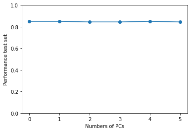

```python
# Random forest with one specific cost parameter
perfNrPcFct(x_spareKog_train, d_train, x_spareKog_test, d_test, meth="randForest",
            pcaRange=range(0,6), param=20, printRes=True)
```

```python
# Fit (again) the PCA
pca_spareKog=PCA()
pca_spareKog.fit(x_spareKog_train)

# print results
print("Explained variance: ")
print(pca_spareKog.explained_variance_ratio_)
print("Loadings: ")
loadings = pd.DataFrame(pca_spareKog.components_.T, columns=['PC1', 'PC2', "PC3", "PC4", "PC5", "PC6"], index=list(data_spareKog.columns))
print(loadings)
```

```
Explained variance:
[0.5720998  0.15255301 0.09184895 0.07395987 0.06375183 0.04578655]
Loadings:
                                  PC1       PC2       PC3       PC4       PC5  \
random_.Intercept._SPARE_AD  0.401598 -0.085981 -0.871356 -0.001743 -0.264134
random_Time_SPARE_AD         0.419534 -0.264519  0.006037 -0.064675  0.774672
random_.Intercept._MMSE     -0.379114 -0.562359 -0.171388 -0.630451  0.119126
random_Time_MMSE            -0.469154  0.031309 -0.121639 -0.164673 -0.168448
random_.Intercept._RAVLT    -0.410520 -0.437040 -0.201815  0.753572  0.167888
random_Time_RAVLT           -0.361042  0.643743 -0.394720 -0.057944  0.509278

                                  PC6
random_.Intercept._SPARE_AD -0.047913
random_Time_SPARE_AD        -0.386890
random_.Intercept._MMSE      0.314629
random_Time_MMSE            -0.841800
random_.Intercept._RAVLT     0.060690
random_Time_RAVLT            0.191621
```

### 3.3) Volume scores of all regions of interest

Again I also used the random effects of all regions of interests. As before I searched for a number of PCs using external criteria rather than only criteria in terms of explained variance as traditionally used for dimenison reduction. Besides the accuracy to predict the diagnosis we also took the explaiend variance of an external continious variable, namely the cogntive decline (operationalized with the random slope in time for the MMSE), as additional criteria for the choice of the number of PCs.

#### Linear and logistic regression

```
#---------- linear regression
```

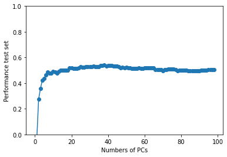

```
#---------- Logistic regression
```

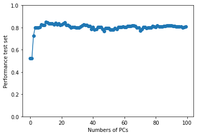

```python
# linear regression predicting random slope in time for MMSE
print("#---------- linear regression")
perfNrPcFct(x_mri_train, y_train, x_mri_test, y_test, meth="linear",
            pcaRange=range(0, 99))

# Logistic regression predicitng the diagnosis
print("#---------- Logistic regression")
perfNrPcFct(x_mri_train, d_train, x_mri_test, d_test, meth="logit",
            pcaRange=range(0, 100))
```

#### Random forest and boosted trees for different hyperparameters

```
#---------- random forest, param=10
```

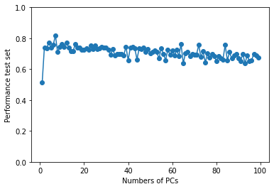

```
#---------- Boosted decision trees, param=10
```

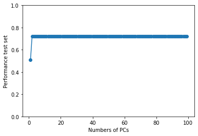

```python
# param=10
print("#---------- random forest, param=10")
perfNrPcFct(x_mri_train, d_train, x_mri_test, d_test, meth="randForest",
            pcaRange=range(1, 100), param=10)

print("#---------- Boosted decision trees, param=10")
perfNrPcFct(x_mri_train, d_train, x_mri_test, d_test, meth="boost",
            pcaRange=range(1, 100), param=10)
```

```
#---------- random forest, param=20
```

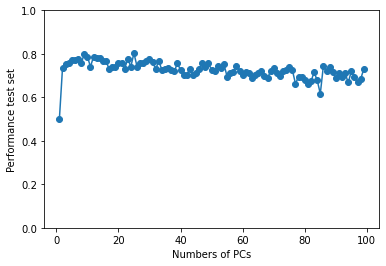

```
#---------- Boosted decision trees, param=20
```

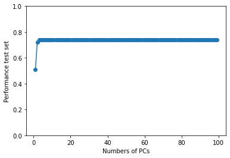

```python
# param=20
print("#---------- random forest, param=20")
perfNrPcFct(x_mri_train, d_train, x_mri_test, d_test, meth="randForest",
            pcaRange=range(1, 100), param=20)

print("#---------- Boosted decision trees, param=20")
perfNrPcFct(x_mri_train, d_train, x_mri_test, d_test, meth="boost",
            pcaRange=range(1, 100), param=20)
```

```
#---------- random forest, param=50
```

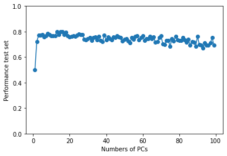

```
#---------- Boosted decision trees, param=50
```

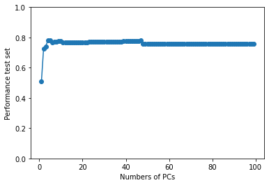

```python
# param=50
print("#---------- random forest, param=50")
perfNrPcFct(x_mri_train, d_train, x_mri_test, d_test, meth="randForest",
            pcaRange=range(1, 100), param=50)

print("#---------- Boosted decision trees, param=50")
perfNrPcFct(x_mri_train, d_train, x_mri_test, d_test, meth="boost",
            pcaRange=range(1, 100), param=50)
```

```
#---------- random forest, param=100
```

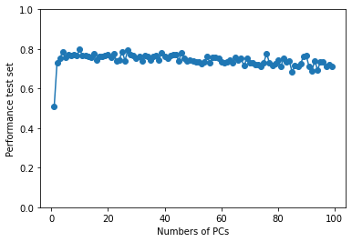

```
#---------- Boosted decision trees, param=100
```

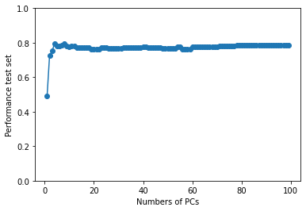

```python
# param=100
print("#---------- random forest, param=100")
perfNrPcFct(x_mri_train, d_train, x_mri_test, d_test, meth="randForest",
            pcaRange=range(1, 100), param=100)

print("#---------- Boosted decision trees, param=100")
perfNrPcFct(x_mri_train, d_train, x_mri_test, d_test, meth="boost",
            pcaRange=range(1, 100), param=100)
```

```
#---------- random forest, param=200
```

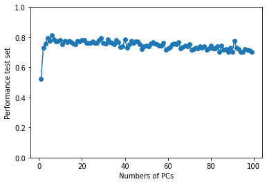

```
#---------- Boosted decision trees, param=200
```

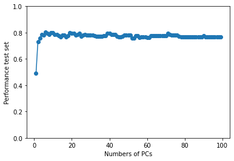

```python
# param=200
print("#---------- random forest, param=200")
perfNrPcFct(x_mri_train, d_train, x_mri_test, d_test, meth="randForest",
            pcaRange=range(1, 100), param=200)

print("#---------- Boosted decision trees, param=200")
perfNrPcFct(x_mri_train, d_train, x_mri_test, d_test, meth="boost",
            pcaRange=range(1, 100), param=200)
```

```
#---------- random forest, param=500
```

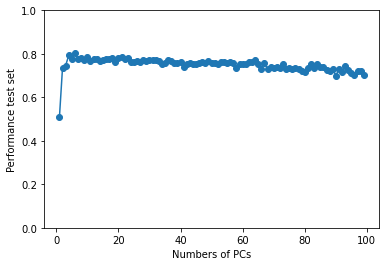

```
#---------- Boosted decision trees, param=500
```

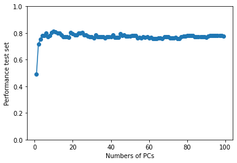

```python
# param=500
print("#---------- random forest, param=500")
perfNrPcFct(x_mri_train, d_train, x_mri_test, d_test, meth="randForest",
            pcaRange=range(1, 100), param=500)

print("#---------- Boosted decision trees, param=500")
perfNrPcFct(x_mri_train, d_train, x_mri_test, d_test, meth="boost",
            pcaRange=range(1, 100), param=500)
```

```
#---------- random forest, param=1000
```

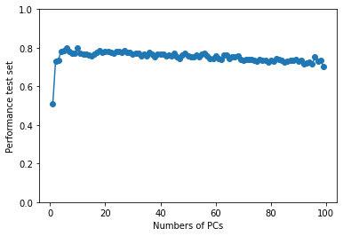

```
#---------- Boosted decision trees, param=1000
```

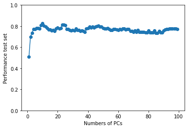

```python
# param=1000
print("#---------- random forest, param=1000")
perfNrPcFct(x_mri_train, d_train, x_mri_test, d_test, meth="randForest",
            pcaRange=range(1, 100), param=1000)

print("#---------- Boosted decision trees, param=1000")
perfNrPcFct(x_mri_train, d_train, x_mri_test, d_test, meth="boost",
            pcaRange=range(1, 100), param=1000)
```

```
#---------- random forest, param=2000
```

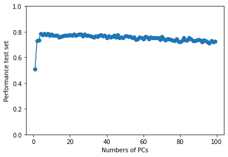

```
#---------- Boosted decision trees, param=2000
```

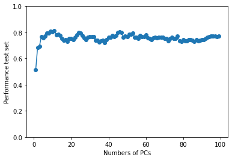

```python
# param=2000
print("#---------- random forest, param=2000")
perfNrPcFct(x_mri_train, d_train, x_mri_test, d_test, meth="randForest",
            pcaRange=range(1, 100), param=2000)

print("#---------- Boosted decision trees, param=2000")
perfNrPcFct(x_mri_train, d_train, x_mri_test, d_test, meth="boost",
            pcaRange=range(1, 100), param=2000)
```

```
#---------- random forest, param=5000
```

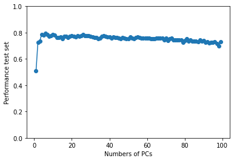

```
#---------- Boosted decision trees, param=5000
```

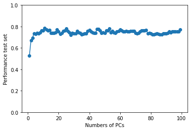

```python
# param=5000
print("#---------- random forest, param=5000")
perfNrPcFct(x_mri_train, d_train, x_mri_test, d_test, meth="randForest",
            pcaRange=range(1, 100), param=5000)

print("#---------- Boosted decision trees, param=5000")
perfNrPcFct(x_mri_train, d_train, x_mri_test, d_test, meth="boost",
            pcaRange=range(1, 100), param=5000)
```

```
#---------- random forest, param=10000
```

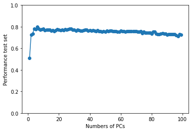

```
#---------- Boosted decision trees, param=10000
```

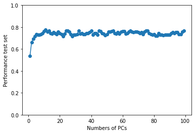

```python
# param=10000
print("#---------- random forest, param=10000")
perfNrPcFct(x_mri_train, d_train, x_mri_test, d_test, meth="randForest",
            pcaRange=range(1, 100), param=10000)

print("#---------- Boosted decision trees, param=10000")
perfNrPcFct(x_mri_train, d_train, x_mri_test, d_test, meth="boost",
            pcaRange=range(1, 100), param=10000)
```

Hence, already with less than 20 PCs performances near maximum (or even the maximum) can be achieved. The more complex machine learning models did not perform better than the simple logistic regression.

In the following we print the exact values of the performance measures from linear and logistic regression.

```
1
training performance= 0.014
test performance= -0.043
2
training performance= 0.014
test performance= -0.043
3
training performance= 0.297
test performance= 0.274
4
training performance= 0.425
test performance= 0.356
5
training performance= 0.496
test performance= 0.421
6
training performance= 0.499
test performance= 0.434
7
training performance= 0.513
test performance= 0.465
8
training performance= 0.523
test performance= 0.485
9
training performance= 0.530
test performance= 0.476
10
training performance= 0.533
test performance= 0.480
11
training performance= 0.536
test performance= 0.493
12
training performance= 0.539
test performance= 0.488
13
training performance= 0.541
test performance= 0.479
14
```

[output cut: 245 more lines]

```
96
training performance= 0.670
test performance= 0.505
97
training performance= 0.671
test performance= 0.504
98
training performance= 0.671
test performance= 0.504
99
training performance= 0.671
test performance= 0.505
100
training performance= 0.673
test performance= 0.507
```

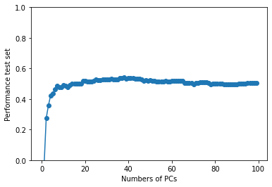

```
1
training performance= 0.576
test performance= 0.523
2
training performance= 0.576
test performance= 0.523
3
training performance= 0.720
test performance= 0.725
4
training performance= 0.722
test performance= 0.798
5
training performance= 0.753
test performance= 0.798
6
training performance= 0.761
test performance= 0.798
7
training performance= 0.776
test performance= 0.803
8
training performance= 0.792
test performance= 0.829
9
training performance= 0.781
test performance= 0.824
10
training performance= 0.781
test performance= 0.824
11
training performance= 0.789
test performance= 0.850
12
training performance= 0.779
test performance= 0.845
13
training performance= 0.776
test performance= 0.834
14
```

[output cut: 245 more lines]

```
96
training performance= 0.897
test performance= 0.808
97
training performance= 0.900
test performance= 0.808
98
training performance= 0.902
test performance= 0.798
99
training performance= 0.900
test performance= 0.803
100
training performance= 0.907
test performance= 0.808
```

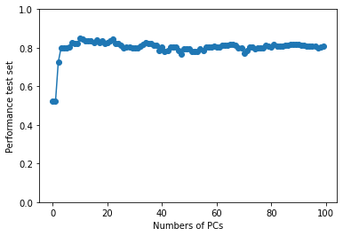

```python
perfNrPcFct(x_mri_train, y_train, x_mri_test, y_test, meth="linear", pcaRange=range(0, 100), printRes=True)
perfNrPcFct(x_mri_train, d_train, x_mri_test, d_test, meth="logit", pcaRange=range(0, 100), printRes=True)
```